# Loan Data Exploration

## 5.0 Bi-variate Exploratory Analysis

### Visualization

```python
# placing numeric variables together and categorical together
numeric_vars = ['LoanOriginalAmount', 'StatedMonthlyIncome', 'DebtToIncomeRatio', 'LoanDuration (months)', 'EmploymentStatusDuration (months)', 'BorrowerRate']
categoric_vars = ['ProsperScore', 'ProsperRating (Alpha)','EmploymentStatus', 'IsBorrowerHomeowner', 'LoanStatus']
```

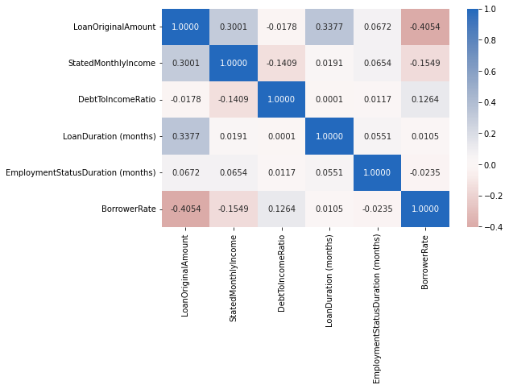

```python
# Correlation Analysis
plt.figure(figsize = [8, 5])
sb.heatmap(loan_copy[numeric_vars].corr(), annot = True, fmt = '.4f', cmap = 'vlag_r', center = 0)
plt.show()
```

### Observation

It is observed from the heat map that there is weak positive correlation between a Borrower's interest rate and the lona duration. There was also a negative correlation between Borrower's interest rate and the monthly income earned

### Question

I want to look at various correlation visuals using scatter plots with different variables

### Visualization

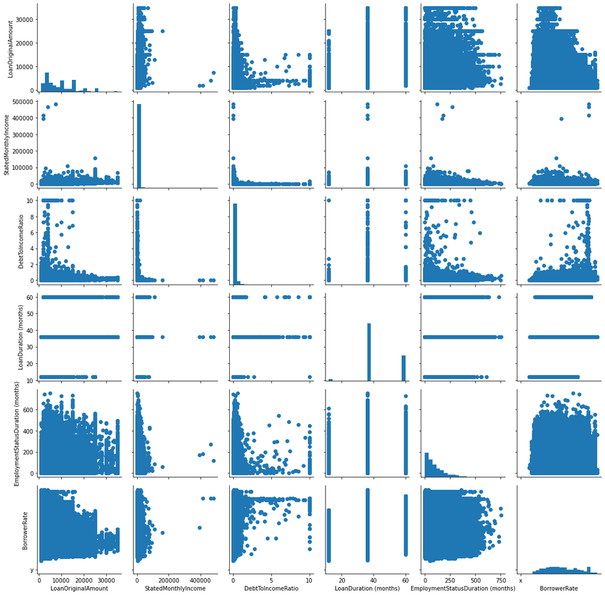

```python
# plot matrix: sample 500 Borrowers so that plots are well rendered
# intoducing jitter and transparency to help with overplotting

samples = np.random.choice(loan_copy.shape[0], 500, replace = False)
g = sb.PairGrid(data = loan_copy, vars = numeric_vars)
plt.plot( 'x', 'y', "", data=loan_copy, linestyle='', marker='o', markersize=0.5, alpha=0.05, color="purple")
g = g.map_diag(plt.hist, bins = 20);
g.map_offdiag(plt.scatter);
```

### Observation

```python
loan_copy['LoanOriginationYear'] = loan_copy['LoanOriginationDate'].dt.year
```

```python
date = loan_copy.LoanOriginationYear.value_counts()
```

[output not shown]

[figure not shown]

```python
fig, ax = plt.subplots(nrows=2, figsize = [12,12])

base_color = sb.color_palette()[0]
Countplot(loan_copy, 'ProsperScore', huevar=None, color=0, palette=None, order=None, ax = ax[0])

Countplot(loan_copy, 'LoanOriginationYear', huevar=None, color=0, palette=None, order=None, ax = ax[1]);
```

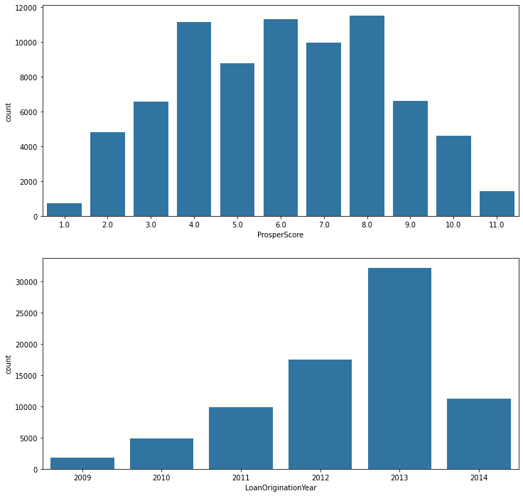

```python
# let's plot all three together to get an idea of each ordinal variable's distribution.

fig, ax = plt.subplots(nrows=2, figsize = [12,12])

base_color = sb.color_palette()[0]

sb.countplot(data = loan_copy, x = 'ProsperScore', color = base_color, ax = ax[0])
sb.countplot(data = loan_copy, x = 'LoanOriginationYear', color = base_color, ax = ax[1])
plt.show()
```

For the Loan Origination Year variable, it is not surprising that 2009 recorded the lowest loan origination count. The financial crisis of 2008 - 2009 is largely responsible for this. However, i am particularly curious as to why 2013 alone contibuted to over 40% of total loan origination count for the perio under review.

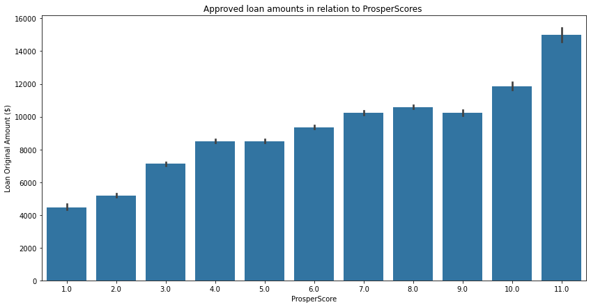

```python
#Correlation between Prosper Score and Loan Origination Amount
plt.figure(figsize=[14,7])
base_color = sb.color_palette()[0]
sb.barplot(data=loan_copy, x='ProsperScore', y='LoanOriginalAmount', color=base_color)
plt.ylabel('Loan Original Amount ($)')
plt.title('Approved loan amounts in relation to ProsperScores ');
```

First thing noticed from this visual is that a perfect Prosper score attracts a higher approved loan amount and vice versa.

## 5. Multivariate Exploration

```python
#Assign values for the analysis
num_var = ['BorrowerRate', 'StatedMonthlyIncome', 'LoanOriginalAmount', 'DebtToIncomeRatio']
cat_var = ['LoanStatus',  'EmploymentStatus', 'EmploymentStatusDuration (months)', 'ProsperScore']
```

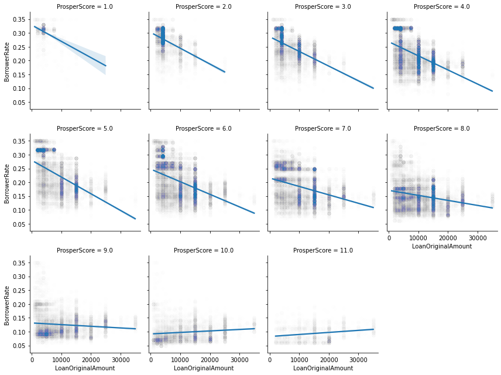

```python
#Plot values to determine effect of Prosper Scores and Amount Borrowed on Borrower Rate
g = sb.FacetGrid(data = loan_copy, col = 'ProsperScore', col_wrap = 4)
g.map(sb.regplot,'LoanOriginalAmount', 'BorrowerRate', x_jitter = 0.05, scatter_kws = {'alpha': 0.005});
```

The above visuals clearly potray that as Prosper Scores improve, the Borrower rate improves as well (decreases) even with increase in Loan Original Amount.

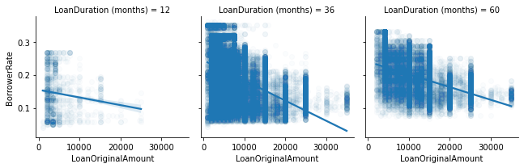

```python
#Identify relationship between Loan amount, Borrower Rate and the Loan Duration
g = sb.FacetGrid(data = loan_copy, col = 'LoanDuration (months)', col_wrap = 4)
g.map(sb.regplot,'LoanOriginalAmount', 'BorrowerRate', x_jitter = 0.05, scatter_kws = {'alpha': 0.02});
```

Generally, loan duration for longer periods attracted relatively higher Borrower Rates. The overall effect of Loan Duration is however not strong.

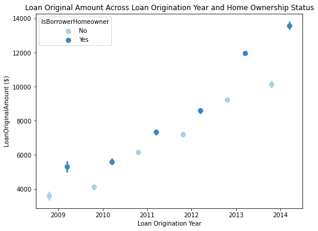

```python
fig = plt.figure(figsize = [8,6])
ax = sb.pointplot(data = loan_copy, x = 'LoanOriginationYear', y = 'LoanOriginalAmount', hue = 'IsBorrowerHomeowner',
           palette = 'Blues', linestyles = '', dodge = 0.4)
plt.title('Loan Original Amount Across Loan Origination Year and Home Ownership Status')
plt.ylabel('LoanOriginalAmount ($)')
plt.xlabel('Loan Origination Year')
plt.show();
```

### Talk about some of the relationships you observed in this part of the investigation. How did the feature(s) of interest vary with other features in the dataset

1. Loan Duration did not factor highly in Borrower rate received as initially expected.
2. Prosper Scores played a huge role in lowering the Borrower Rate received by borrowers
3. For the most part, Borrowers who owned homes were approved for larger loans than borrowers without homes.

### Were there any interesting or surprising interactions between features?

I initially thought longer term loans would carry higher borrower rates to factor for risk, but the analysis showed that effect of loan duration was not as impactful on borrower rate.